# main

diamond 문제

```python
import seaborn
import pandas

df = seaborn.load_dataset("diamonds")
df.head(3)
```

|  | carat | cut | color | clarity | depth | table | price | x | y | z |
| --- | --- | --- | --- | --- | --- | --- | --- | --- | --- | --- |
| 0 | 0.23 | Ideal | E | SI2 | 61.5 | 55.0 | 326 | 3.95 | 3.98 | 2.43 |
| 1 | 0.21 | Premium | E | SI1 | 59.8 | 61.0 | 326 | 3.89 | 3.84 | 2.31 |
| 2 | 0.23 | Good | E | VS1 | 56.9 | 65.0 | 327 | 4.05 | 4.07 | 2.31 |

데이터셋을 불러오면 10*53940 크기의 데이터프레임을 불러올 수 있음

| 필드명 | 설명 |
| --- | --- |
| carat | 무게 |
| cut | 컷팅 품질 |
| color | 색상 |
| clarity | 투명도 |
| depth | 깊이 ( `2 * z / (x + y)`) |
| table | 테이블 |
| price | 가격 |
| x | 길이(mm) |
| y | 너비(mm) |
| z | 깊이(mm) |

다이아몬드의 가격을 종속 변수로 하는 모델을 학습해야함.

앞서 주어진 데이터를 목적에 맞게 분리하려고함

- 학습용
- 검증용
- 평가용 (테스트용)

## Q1. 데이터 분할

- 전체 데이터의 40%를 학습 데이터, 40%를 검증 데이터, 20%를 평가 데이터로 분류하는 코드 작성
- random_state 파라미터를 사용하되 값은 자유롭게 지정

```python
from sklearn.model_selection import train_test_split
train_df, temp_df = train_test_split(df, train_size=0.4, random_state=54)
valid_df, test_df = train_test_split(temp_df, train_size=0.66667, random_state=28)

print("전체 데이터 샘플: ", df.shape)
print("학습 데이터 샘플: ", train_df.shape)
print("검증 데이터 샘플: ", valid_df.shape)
print("테스트 데이터 샘플: ", test_df.shape)
```

```
전체 데이터 샘플:  (53940, 10)
학습 데이터 샘플:  (21576, 10)
검증 데이터 샘플:  (21576, 10)
테스트 데이터 샘플:  (10788, 10)
```

## Q2. 데이터 분포 확인

`pandas.DataFrame.describe()` 메서드와 `pandas.DataFrame.hist()`를 이용하여 학습 데이터와 평가 데이터의 각 칼럼들의 값 분포에 대하여 논의하여라.

학습 데이터와 평가 데이터는 다른 분포를 가지는가? 비슷한 분포를 가지는가?

```python
import matplotlib.pyplot as plt
```

```
array([[<Axes: title={'center': 'carat'}>,
        <Axes: title={'center': 'depth'}>,
        <Axes: title={'center': 'table'}>],
       [<Axes: title={'center': 'price'}>, <Axes: title={'center': 'x'}>,
        <Axes: title={'center': 'y'}>],
       [<Axes: title={'center': 'z'}>, <Axes: >, <Axes: >]], dtype=object)
```

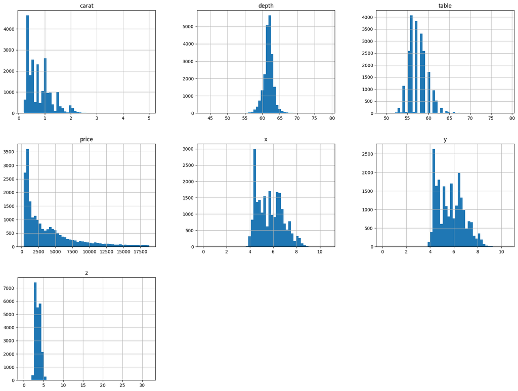

```python
# pandas.DataFrame.describe() 함수를 사용하여 학습데이터의 통계 정보를 확인합니다.
train_df.describe()

# 히스토그램
train_df.hist(bins=50, figsize=(20,15))
```

```
array([[<Axes: title={'center': 'carat'}>,
        <Axes: title={'center': 'depth'}>,
        <Axes: title={'center': 'table'}>],
       [<Axes: title={'center': 'price'}>, <Axes: title={'center': 'x'}>,
        <Axes: title={'center': 'y'}>],
       [<Axes: title={'center': 'z'}>, <Axes: >, <Axes: >]], dtype=object)
```

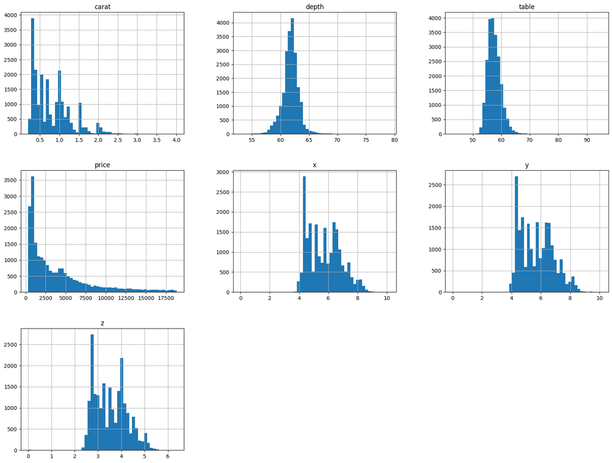

```python
# pandas.DataFrame.describe() 함수를 사용하여 평가데이터의 통계 정보를 확인합니다.
valid_df.describe()

# 히스토그램
valid_df.hist(bins=50, figsize=(20,15))
```

히스토그램을 기준으로 비교해보면 동일한 양상을 띄고있음

둘을 나란히 비교하기위해 겹쳐서 그려보면 더 명확하게 확인할 수 있음

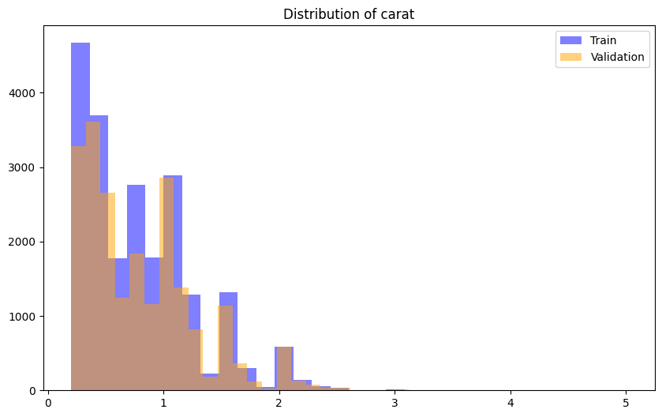

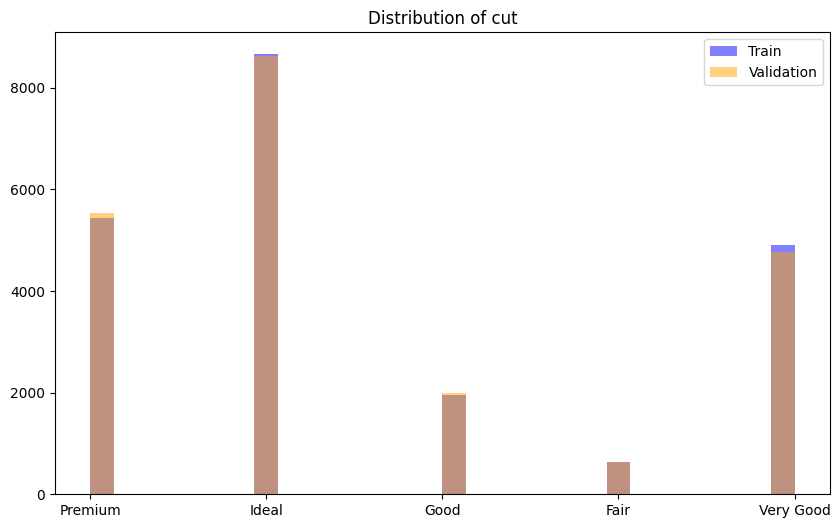

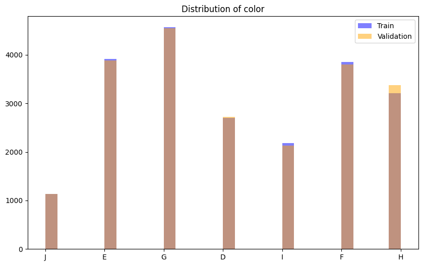

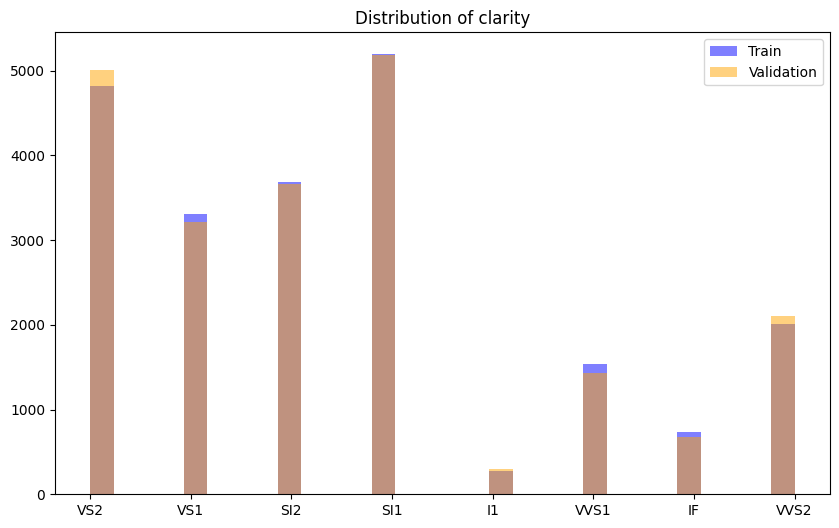

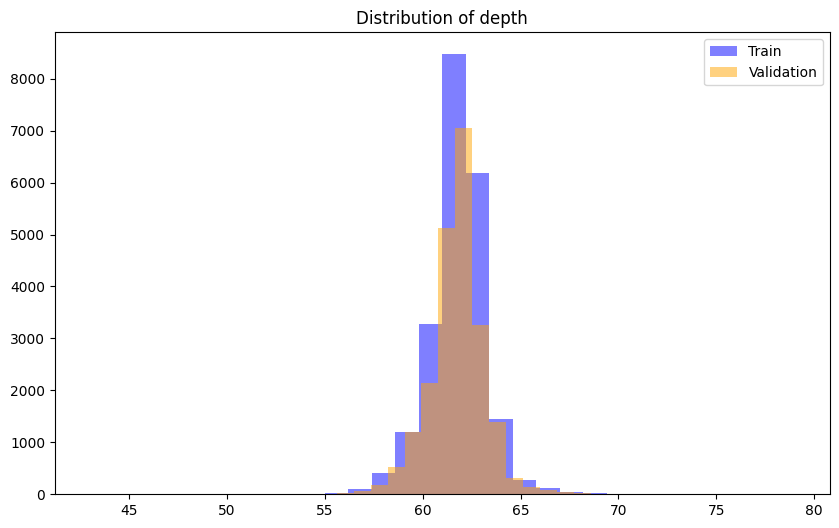

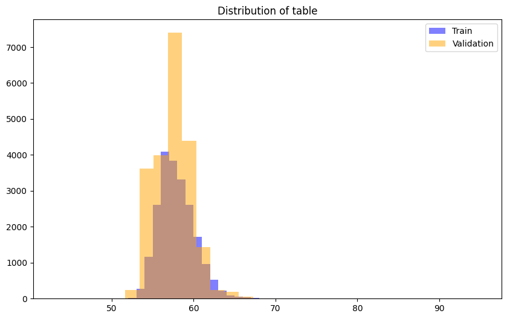

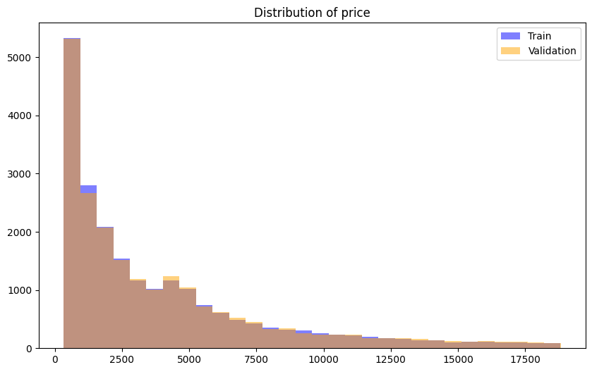

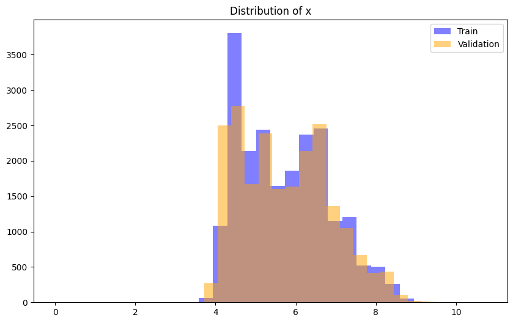

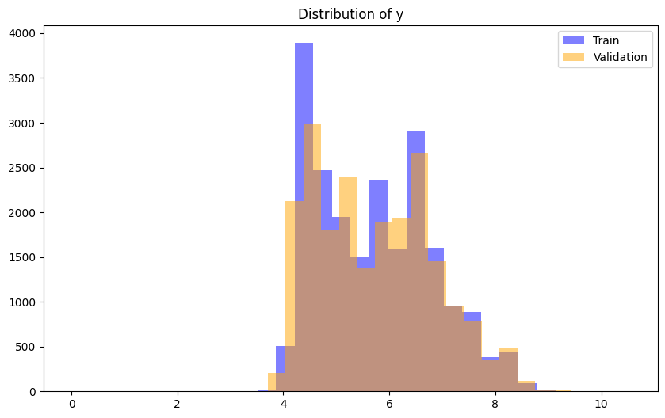

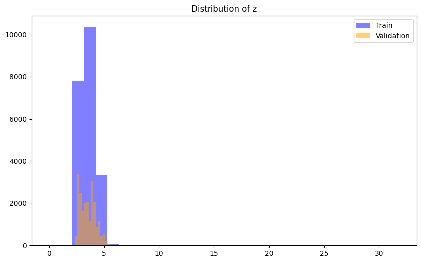

```python
import matplotlib.pyplot as plt

# 학습 및 검증 데이터셋의 컬럼별 분포를 비교
features = train_df.columns
for feature in features:
    plt.figure(figsize=(10, 6))
    plt.hist(train_df[feature], bins=30, alpha=0.5, label='Train', color='blue')
    plt.hist(valid_df[feature], bins=30, alpha=0.5, label='Validation', color='orange')
    plt.title(f'Distribution of {feature}')
    plt.legend()
    plt.show()
```

## Q3. 모델 학습

`pandas.DataFrame.plot.box()` 메서드를 이용하여 학습 데이터와 평가 데이터의 종속 변수(price)의 분포를 상자 그림으로 나타내고 두 종속 변수의 분포에 대하여 논의하여라.

학습 데이터와 평가 데이터는 다른 분포를 보이는가? 비슷한 분포를 보이는가?

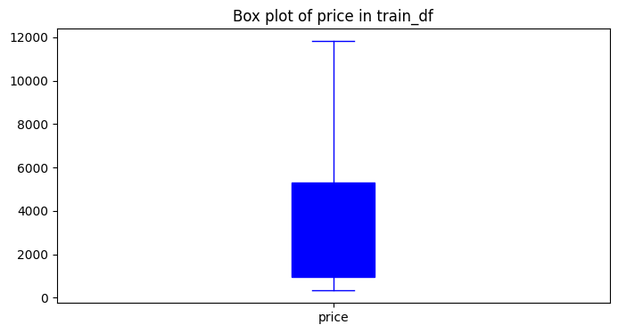

```python
# train_df 에 대한 box plot
plt.figure(figsize=(8, 4))
train_df['price'].plot.box(color='blue', patch_artist=True, showfliers=False)
plt.title('Box plot of price in train_df')
plt.show()
```

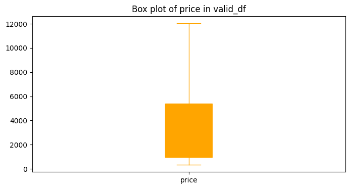

```python
# `pandas.DataFrame.plot.box()` 메서드를 이용하여 학습 데이터와 평가 데이터의 종속 변수(price)의 분포를 상자 그림으로 나타내고 두 종속 변수의 분포에 대하여 논의하여라.
plt.figure(figsize=(8, 4))
valid_df['price'].plot.box(color='orange', patch_artist=True, showfliers=False)
plt.title('Box plot of price in valid_df')
plt.show()
```

수염의 길이나 price 중앙값, 사분위 범위가 얼추 비슷해보임

조금 더 명확히 비교하기 위해 두 데이터셋을 겹쳐서 그려보면 더 명확하게 확인할 수 있음

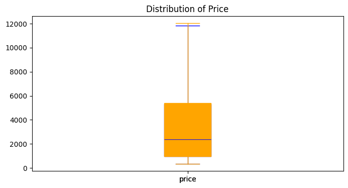

```python
# `pandas.DataFrame.plot.box()` 메서드를 이용하여 학습 데이터와 평가 데이터의 종속 변수(price)의 분포를 상자 그림으로 나타내고 두 종속 변수의 분포에 대하여 논의하여라.
plt.figure(figsize=(8, 4))
train_df['price'].plot.box(color='blue', patch_artist=True, showfliers=False)
valid_df['price'].plot.box(color='orange', patch_artist=True, showfliers=False)
plt.title('Distribution of Price')
plt.show()
```

- 박스를 보면 price 컬럼에 대한 train data와 valid data의 분포가 대체로 유사해보임
- 두 데이터셋 모두 price의 중앙값과 사분위 범위가 비슷해보임.
- 상자와 수염의 길이도 유사한 것을 확인할 수 있음.
  - 두 데이터셋이 price 변수에 대해 유사한 분포를 가지고 있다고 판단됨.

큰 차이는 없어보이기 때문에, 학습 및 검증 데이터의 분포가 비교적 유사하다고 판단됨.

```python
from scipy.stats import ks_2samp

for column in train_df.columns:
    stat, p_value = ks_2samp(train_df[column], valid_df[column])
    print(f"{column}: KS-statistic={stat:.4f}, p-value={p_value:.4f}")
```

```
carat: KS-statistic=0.0119, p-value=0.0929
cut: KS-statistic=0.0063, p-value=0.7746
color: KS-statistic=0.0048, p-value=0.9625
clarity: KS-statistic=0.0073, p-value=0.6147
depth: KS-statistic=0.0066, p-value=0.7278
table: KS-statistic=0.0145, p-value=0.0211
price: KS-statistic=0.0098, p-value=0.2470
x: KS-statistic=0.0108, p-value=0.1569
y: KS-statistic=0.0116, p-value=0.1070
z: KS-statistic=0.0105, p-value=0.1860
```

Kolmogorov-Smirnov 테스트는 두 데이터셋의 분포가 동일한지를 통계적으로 테스트해주는 방법임